# Risk Factor Analysis

## Outcome Variable

**Outcome Variable:** wast_rec90d

## Predictor Variables

**Intervention Variable:** earlybf

**Adjustment Set:**

- arm
- sex
- W_mage
- meducyrs
- feducyrs
- hhwealth_quart
- hfoodsec
- W_mhtcm
- vagbrth
- W_birthwt
- W_birthlen
- W_nrooms
- W_nchldlt5
- brthmon
- W_parity
- impfloor
- impsan
- safeh20
- delta_W_mage
- delta_meducyrs
- delta_feducyrs
- delta_hhwealth_quart
- delta_hfoodsec
- delta_W_mhtcm
- delta_vagbrth
- delta_W_birthwt
- delta_W_birthlen
- delta_W_nrooms
- delta_W_nchldlt5
- delta_brthmon
- delta_W_parity
- delta_impfloor
- delta_impsan
- delta_safeh20

## Stratifying Variables

The analysis was stratified on these variable(s):

- agecat
- studyid
- country

## Data Summary

| agecat | studyid | country | earlybf | wast_rec90d | n_cell | n |
| --- | --- | --- | --- | --- | --- | --- |
| 0-24 months | ki0047075b-MAL-ED | BANGLADESH | 1 | 0 | 26 | 122 |
| 0-24 months | ki0047075b-MAL-ED | BANGLADESH | 1 | 1 | 46 | 122 |
| 0-24 months | ki0047075b-MAL-ED | BANGLADESH | 0 | 0 | 18 | 122 |
| 0-24 months | ki0047075b-MAL-ED | BANGLADESH | 0 | 1 | 32 | 122 |
| 0-24 months | ki0047075b-MAL-ED | BRAZIL | 1 | 0 | 3 | 23 |
| 0-24 months | ki0047075b-MAL-ED | BRAZIL | 1 | 1 | 5 | 23 |
| 0-24 months | ki0047075b-MAL-ED | BRAZIL | 0 | 0 | 3 | 23 |
| 0-24 months | ki0047075b-MAL-ED | BRAZIL | 0 | 1 | 12 | 23 |
| 0-24 months | ki0047075b-MAL-ED | INDIA | 1 | 0 | 44 | 178 |
| 0-24 months | ki0047075b-MAL-ED | INDIA | 1 | 1 | 62 | 178 |
| 0-24 months | ki0047075b-MAL-ED | INDIA | 0 | 0 | 27 | 178 |
| 0-24 months | ki0047075b-MAL-ED | INDIA | 0 | 1 | 45 | 178 |
| 0-24 months | ki0047075b-MAL-ED | NEPAL | 1 | 0 | 9 | 93 |
| 0-24 months | ki0047075b-MAL-ED | NEPAL | 1 | 1 | 33 | 93 |
| 0-24 months | ki0047075b-MAL-ED | NEPAL | 0 | 0 | 11 | 93 |
| 0-24 months | ki0047075b-MAL-ED | NEPAL | 0 | 1 | 40 | 93 |
| 0-24 months | ki0047075b-MAL-ED | PERU | 1 | 0 | 5 | 34 |
| 0-24 months | ki0047075b-MAL-ED | PERU | 1 | 1 | 25 | 34 |
| 0-24 months | ki0047075b-MAL-ED | PERU | 0 | 0 | 1 | 34 |
| 0-24 months | ki0047075b-MAL-ED | PERU | 0 | 1 | 3 | 34 |
| 0-24 months | ki0047075b-MAL-ED | SOUTH AFRICA | 1 | 0 | 8 | 80 |
| 0-24 months | ki0047075b-MAL-ED | SOUTH AFRICA | 1 | 1 | 42 | 80 |
| 0-24 months | ki0047075b-MAL-ED | SOUTH AFRICA | 0 | 0 | 6 | 80 |
| 0-24 months | ki0047075b-MAL-ED | SOUTH AFRICA | 0 | 1 | 24 | 80 |
| 0-24 months | ki0047075b-MAL-ED | TANZANIA, UNITED REPUBLIC OF | 1 | 0 | 6 | 45 |
| 0-24 months | ki0047075b-MAL-ED | TANZANIA, UNITED REPUBLIC OF | 1 | 1 | 35 | 45 |
| 0-24 months | ki0047075b-MAL-ED | TANZANIA, UNITED REPUBLIC OF | 0 | 0 | 2 | 45 |
| 0-24 months | ki0047075b-MAL-ED | TANZANIA, UNITED REPUBLIC OF | 0 | 1 | 2 | 45 |
| 0-24 months | ki1000109-EE | PAKISTAN | 1 | 0 | 23 | 257 |
| 0-24 months | ki1000109-EE | PAKISTAN | 1 | 1 | 14 | 257 |

[output cut: 138 more lines]

The following strata were considered:

- agecat: 0-24 months, studyid: ki0047075b-MAL-ED, country: BANGLADESH
- agecat: 0-24 months, studyid: ki0047075b-MAL-ED, country: BRAZIL
- agecat: 0-24 months, studyid: ki0047075b-MAL-ED, country: INDIA
- agecat: 0-24 months, studyid: ki0047075b-MAL-ED, country: NEPAL
- agecat: 0-24 months, studyid: ki0047075b-MAL-ED, country: PERU
- agecat: 0-24 months, studyid: ki0047075b-MAL-ED, country: SOUTH AFRICA
- agecat: 0-24 months, studyid: ki0047075b-MAL-ED, country: TANZANIA, UNITED REPUBLIC OF
- agecat: 0-24 months, studyid: ki1000109-EE, country: PAKISTAN
- agecat: 0-24 months, studyid: ki1000304b-SAS-CompFeed, country: INDIA
- agecat: 0-24 months, studyid: ki1017093c-NIH-Crypto, country: BANGLADESH
- agecat: 0-24 months, studyid: ki1113344-GMS-Nepal, country: NEPAL
- agecat: 0-24 months, studyid: ki1126311-ZVITAMBO, country: ZIMBABWE
- agecat: 0-24 months, studyid: kiGH5241-JiVitA-3, country: BANGLADESH
- agecat: 0-24 months, studyid: kiGH5241-JiVitA-4, country: BANGLADESH
- agecat: 0-6 months, studyid: ki0047075b-MAL-ED, country: BANGLADESH
- agecat: 0-6 months, studyid: ki0047075b-MAL-ED, country: BRAZIL
- agecat: 0-6 months, studyid: ki0047075b-MAL-ED, country: INDIA
- agecat: 0-6 months, studyid: ki0047075b-MAL-ED, country: NEPAL
- agecat: 0-6 months, studyid: ki0047075b-MAL-ED, country: PERU
- agecat: 0-6 months, studyid: ki0047075b-MAL-ED, country: SOUTH AFRICA
- agecat: 0-6 months, studyid: ki0047075b-MAL-ED, country: TANZANIA, UNITED REPUBLIC OF
- agecat: 0-6 months, studyid: ki1000109-EE, country: PAKISTAN
- agecat: 0-6 months, studyid: ki1000304b-SAS-CompFeed, country: INDIA
- agecat: 0-6 months, studyid: ki1017093c-NIH-Crypto, country: BANGLADESH
- agecat: 0-6 months, studyid: ki1113344-GMS-Nepal, country: NEPAL
- agecat: 0-6 months, studyid: ki1126311-ZVITAMBO, country: ZIMBABWE
- agecat: 0-6 months, studyid: kiGH5241-JiVitA-3, country: BANGLADESH
- agecat: 0-6 months, studyid: kiGH5241-JiVitA-4, country: BANGLADESH
- agecat: 6-24 months, studyid: ki0047075b-MAL-ED, country: BANGLADESH
- agecat: 6-24 months, studyid: ki0047075b-MAL-ED, country: BRAZIL
- agecat: 6-24 months, studyid: ki0047075b-MAL-ED, country: INDIA
- agecat: 6-24 months, studyid: ki0047075b-MAL-ED, country: NEPAL
- agecat: 6-24 months, studyid: ki0047075b-MAL-ED, country: PERU
- agecat: 6-24 months, studyid: ki0047075b-MAL-ED, country: SOUTH AFRICA
- agecat: 6-24 months, studyid: ki0047075b-MAL-ED, country: TANZANIA, UNITED REPUBLIC OF
- agecat: 6-24 months, studyid: ki1000109-EE, country: PAKISTAN
- agecat: 6-24 months, studyid: ki1000304b-SAS-CompFeed, country: INDIA
- agecat: 6-24 months, studyid: ki1017093c-NIH-Crypto, country: BANGLADESH
- agecat: 6-24 months, studyid: ki1113344-GMS-Nepal, country: NEPAL
- agecat: 6-24 months, studyid: ki1126311-ZVITAMBO, country: ZIMBABWE
- agecat: 6-24 months, studyid: kiGH5241-JiVitA-3, country: BANGLADESH
- agecat: 6-24 months, studyid: kiGH5241-JiVitA-4, country: BANGLADESH

### Dropped Strata

Some strata were dropped due to rare outcomes:

- agecat: 0-24 months, studyid: ki0047075b-MAL-ED, country: BRAZIL
- agecat: 0-24 months, studyid: ki0047075b-MAL-ED, country: PERU
- agecat: 0-24 months, studyid: ki0047075b-MAL-ED, country: TANZANIA, UNITED REPUBLIC OF
- agecat: 0-6 months, studyid: ki0047075b-MAL-ED, country: BRAZIL
- agecat: 0-6 months, studyid: ki0047075b-MAL-ED, country: NEPAL
- agecat: 0-6 months, studyid: ki0047075b-MAL-ED, country: PERU
- agecat: 0-6 months, studyid: ki0047075b-MAL-ED, country: SOUTH AFRICA
- agecat: 0-6 months, studyid: ki0047075b-MAL-ED, country: TANZANIA, UNITED REPUBLIC OF
- agecat: 6-24 months, studyid: ki0047075b-MAL-ED, country: BRAZIL
- agecat: 6-24 months, studyid: ki0047075b-MAL-ED, country: NEPAL
- agecat: 6-24 months, studyid: ki0047075b-MAL-ED, country: PERU
- agecat: 6-24 months, studyid: ki0047075b-MAL-ED, country: SOUTH AFRICA
- agecat: 6-24 months, studyid: ki0047075b-MAL-ED, country: TANZANIA, UNITED REPUBLIC OF
- agecat: 6-24 months, studyid: ki1017093c-NIH-Crypto, country: BANGLADESH
- agecat: 6-24 months, studyid: kiGH5241-JiVitA-3, country: BANGLADESH

## Methods Detail

We’re interested in the causal parameters $E[Y_a]$ for all values of $a \in \mathcal{A}$. These parameters represent the mean outcome if, possibly contrary to fact, we intervened to set all units to have $A=a$. Under the randomization and positivity assumptions, these are identified by the statistical parameters $\psi_a=E_W[E_{Y|A,W}(Y|A=a,W)]$. In addition, we’re interested in the mean of $Y$, $E[Y]$ under no intervention (the observed mean). We will estimate these parameters by using SuperLearner to fit the relevant likelihood factors – $E_{Y|A,W}(Y|A=a,W)$ and $p(A=a|W)$, and then updating our likelihood fit using a joint TMLE.

For unadjusted analyses ($W=\{\}$), initial likelihoods were estimated using Lrnr_glm to estimate the simple $E(Y|A)$ and Lrnr_mean to estimate $p(A)$. For adjusted analyses, a small library containing Lrnr_glmnet, Lrnr_xgboost, and Lrnr_mean was used.

Having estimated these parameters, we will then use the delta method to estimate relative risks and attributable risks relative to a prespecified baseline level of $A$.

# Results Detail

## Results Plots

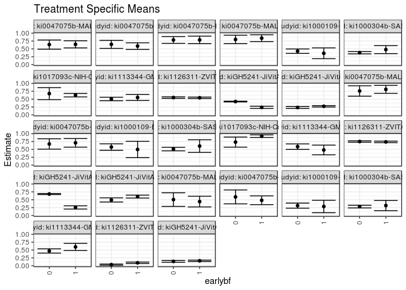

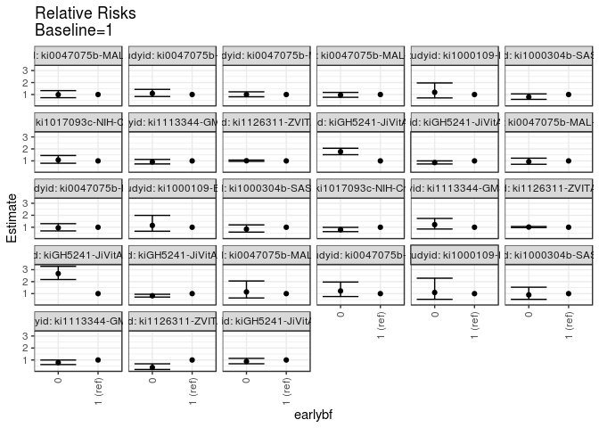

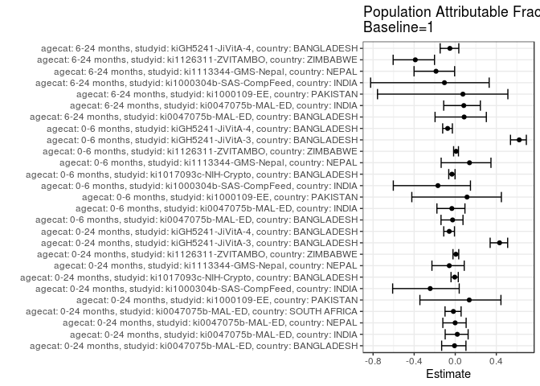

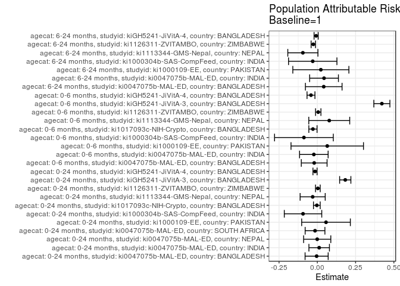

## Results Table

### Parameter: TSM

| agecat | studyid | country | intervention_level | baseline_level | estimate | ci_lower | ci_upper |
| --- | --- | --- | --- | --- | --- | --- | --- |
| 0-24 months | ki0047075b-MAL-ED | BANGLADESH | 1 | NA | 0.6438928 | 0.5299758 | 0.7578098 |
| 0-24 months | ki0047075b-MAL-ED | BANGLADESH | 0 | NA | 0.6358449 | 0.4901332 | 0.7815567 |
| 0-24 months | ki0047075b-MAL-ED | INDIA | 1 | NA | 0.5890487 | 0.4847628 | 0.6933346 |
| 0-24 months | ki0047075b-MAL-ED | INDIA | 0 | NA | 0.6435810 | 0.5142686 | 0.7728934 |
| 0-24 months | ki0047075b-MAL-ED | NEPAL | 1 | NA | 0.7857143 | 0.6655613 | 0.9058673 |
| 0-24 months | ki0047075b-MAL-ED | NEPAL | 0 | NA | 0.7843137 | 0.6765475 | 0.8920799 |
| 0-24 months | ki0047075b-MAL-ED | SOUTH AFRICA | 1 | NA | 0.8400000 | 0.7318211 | 0.9481789 |
| 0-24 months | ki0047075b-MAL-ED | SOUTH AFRICA | 0 | NA | 0.8000000 | 0.6657395 | 0.9342605 |
| 0-24 months | ki1000109-EE | PAKISTAN | 1 | NA | 0.3595853 | 0.1887303 | 0.5304403 |
| 0-24 months | ki1000109-EE | PAKISTAN | 0 | NA | 0.4270030 | 0.3564210 | 0.4975850 |
| 0-24 months | ki1000304b-SAS-CompFeed | INDIA | 1 | NA | 0.4760922 | 0.3488977 | 0.6032866 |
| 0-24 months | ki1000304b-SAS-CompFeed | INDIA | 0 | NA | 0.3777987 | 0.3412567 | 0.4143406 |
| 0-24 months | ki1017093c-NIH-Crypto | BANGLADESH | 1 | NA | 0.6269636 | 0.5707275 | 0.6831997 |
| 0-24 months | ki1017093c-NIH-Crypto | BANGLADESH | 0 | NA | 0.6761927 | 0.4853104 | 0.8670750 |
| 0-24 months | ki1113344-GMS-Nepal | NEPAL | 1 | NA | 0.5531687 | 0.4571680 | 0.6491695 |
| 0-24 months | ki1113344-GMS-Nepal | NEPAL | 0 | NA | 0.5060809 | 0.4513304 | 0.5608313 |
| 0-24 months | ki1126311-ZVITAMBO | ZIMBABWE | 1 | NA | 0.5438165 | 0.5207062 | 0.5669267 |
| 0-24 months | ki1126311-ZVITAMBO | ZIMBABWE | 0 | NA | 0.5507973 | 0.5282283 | 0.5733663 |
| 0-24 months | kiGH5241-JiVitA-3 | BANGLADESH | 1 | NA | 0.2403443 | 0.2045238 | 0.2761648 |
| 0-24 months | kiGH5241-JiVitA-3 | BANGLADESH | 0 | NA | 0.4242741 | 0.4129092 | 0.4356390 |
| 0-24 months | kiGH5241-JiVitA-4 | BANGLADESH | 1 | NA | 0.2736763 | 0.2500578 | 0.2972947 |
| 0-24 months | kiGH5241-JiVitA-4 | BANGLADESH | 0 | NA | 0.2354963 | 0.2052174 | 0.2657752 |
| 0-6 months | ki0047075b-MAL-ED | BANGLADESH | 1 | NA | 0.8108108 | 0.6847315 | 0.9368901 |
| 0-6 months | ki0047075b-MAL-ED | BANGLADESH | 0 | NA | 0.7600000 | 0.5939976 | 0.9260024 |
| 0-6 months | ki0047075b-MAL-ED | INDIA | 1 | NA | 0.7094453 | 0.5729459 | 0.8459446 |
| 0-6 months | ki0047075b-MAL-ED | INDIA | 0 | NA | 0.6746526 | 0.5097057 | 0.8395994 |
| 0-6 months | ki1000109-EE | PAKISTAN | 1 | NA | 0.5000000 | 0.2418553 | 0.7581447 |
| 0-6 months | ki1000109-EE | PAKISTAN | 0 | NA | 0.5760870 | 0.4734543 | 0.6787196 |
| 0-6 months | ki1000304b-SAS-CompFeed | INDIA | 1 | NA | 0.6068470 | 0.4061444 | 0.8075497 |
| 0-6 months | ki1000304b-SAS-CompFeed | INDIA | 0 | NA | 0.5128977 | 0.4564875 | 0.5693079 |
| 0-6 months | ki1017093c-NIH-Crypto | BANGLADESH | 1 | NA | 0.9226190 | 0.8817191 | 0.9635190 |
| 0-6 months | ki1017093c-NIH-Crypto | BANGLADESH | 0 | NA | 0.7333333 | 0.5730670 | 0.8935997 |
| 0-6 months | ki1113344-GMS-Nepal | NEPAL | 1 | NA | 0.4830956 | 0.3279707 | 0.6382205 |
| 0-6 months | ki1113344-GMS-Nepal | NEPAL | 0 | NA | 0.5888221 | 0.5006263 | 0.6770180 |
| 0-6 months | ki1126311-ZVITAMBO | ZIMBABWE | 1 | NA | 0.7401205 | 0.7150132 | 0.7652277 |
| 0-6 months | ki1126311-ZVITAMBO | ZIMBABWE | 0 | NA | 0.7522369 | 0.7289795 | 0.7754943 |
| 0-6 months | kiGH5241-JiVitA-3 | BANGLADESH | 1 | NA | 0.2549784 | 0.2029163 | 0.3070405 |
| 0-6 months | kiGH5241-JiVitA-3 | BANGLADESH | 0 | NA | 0.6810621 | 0.6675116 | 0.6946127 |
| 0-6 months | kiGH5241-JiVitA-4 | BANGLADESH | 1 | NA | 0.6001704 | 0.5539982 | 0.6463425 |
| 0-6 months | kiGH5241-JiVitA-4 | BANGLADESH | 0 | NA | 0.4931214 | 0.4269084 | 0.5593344 |
| 6-24 months | ki0047075b-MAL-ED | BANGLADESH | 1 | NA | 0.4414833 | 0.2708187 | 0.6121478 |
| 6-24 months | ki0047075b-MAL-ED | BANGLADESH | 0 | NA | 0.5050090 | 0.2885702 | 0.7214478 |
| 6-24 months | ki0047075b-MAL-ED | INDIA | 1 | NA | 0.4824578 | 0.3427906 | 0.6221249 |
| 6-24 months | ki0047075b-MAL-ED | INDIA | 0 | NA | 0.5892762 | 0.3682309 | 0.8103215 |
| 6-24 months | ki1000109-EE | PAKISTAN | 1 | NA | 0.2857143 | 0.0885683 | 0.4828603 |
| 6-24 months | ki1000109-EE | PAKISTAN | 0 | NA | 0.3125000 | 0.2313361 | 0.3936639 |
| 6-24 months | ki1000304b-SAS-CompFeed | INDIA | 1 | NA | 0.3154179 | 0.1517283 | 0.4791074 |
| 6-24 months | ki1000304b-SAS-CompFeed | INDIA | 0 | NA | 0.2823407 | 0.2390727 | 0.3256087 |
| 6-24 months | ki1113344-GMS-Nepal | NEPAL | 1 | NA | 0.5988105 | 0.4853830 | 0.7122380 |
| 6-24 months | ki1113344-GMS-Nepal | NEPAL | 0 | NA | 0.4704672 | 0.4024486 | 0.5384857 |
| 6-24 months | ki1126311-ZVITAMBO | ZIMBABWE | 1 | NA | 0.0937571 | 0.0690955 | 0.1184187 |
| 6-24 months | ki1126311-ZVITAMBO | ZIMBABWE | 0 | NA | 0.0350715 | 0.0163169 | 0.0538261 |
| 6-24 months | kiGH5241-JiVitA-4 | BANGLADESH | 1 | NA | 0.1568671 | 0.1345649 | 0.1791692 |
| 6-24 months | kiGH5241-JiVitA-4 | BANGLADESH | 0 | NA | 0.1382730 | 0.1090197 | 0.1675262 |

### Parameter: E(Y)

| agecat | studyid | country | intervention_level | baseline_level | estimate | ci_lower | ci_upper |
| --- | --- | --- | --- | --- | --- | --- | --- |
| 0-24 months | ki0047075b-MAL-ED | BANGLADESH | NA | NA | 0.6393443 | 0.5524803 | 0.7262082 |
| 0-24 months | ki0047075b-MAL-ED | INDIA | NA | NA | 0.6011236 | 0.5212729 | 0.6809743 |
| 0-24 months | ki0047075b-MAL-ED | NEPAL | NA | NA | 0.7849462 | 0.7049947 | 0.8648978 |
| 0-24 months | ki0047075b-MAL-ED | SOUTH AFRICA | NA | NA | 0.8250000 | 0.7407860 | 0.9092140 |
| 0-24 months | ki1000109-EE | PAKISTAN | NA | NA | 0.4163424 | 0.3511349 | 0.4815500 |
| 0-24 months | ki1000304b-SAS-CompFeed | INDIA | NA | NA | 0.3827160 | 0.3474971 | 0.4179350 |
| 0-24 months | ki1017093c-NIH-Crypto | BANGLADESH | NA | NA | 0.6237942 | 0.5698223 | 0.6777662 |
| 0-24 months | ki1113344-GMS-Nepal | NEPAL | NA | NA | 0.5227723 | 0.4753649 | 0.5701796 |
| 0-24 months | ki1126311-ZVITAMBO | ZIMBABWE | NA | NA | 0.5472806 | 0.5299898 | 0.5645714 |
| 0-24 months | kiGH5241-JiVitA-3 | BANGLADESH | NA | NA | 0.4228126 | 0.4116855 | 0.4339397 |
| 0-24 months | kiGH5241-JiVitA-4 | BANGLADESH | NA | NA | 0.2585790 | 0.2392503 | 0.2779077 |
| 0-6 months | ki0047075b-MAL-ED | BANGLADESH | NA | NA | 0.7903226 | 0.6894772 | 0.8911679 |
| 0-6 months | ki0047075b-MAL-ED | INDIA | NA | NA | 0.6867470 | 0.5837430 | 0.7897510 |
| 0-6 months | ki1000109-EE | PAKISTAN | NA | NA | 0.5648148 | 0.4692893 | 0.6603404 |
| 0-6 months | ki1000304b-SAS-CompFeed | INDIA | NA | NA | 0.5192878 | 0.4654446 | 0.5731311 |
| 0-6 months | ki1017093c-NIH-Crypto | BANGLADESH | NA | NA | 0.8939394 | 0.8505280 | 0.9373508 |
| 0-6 months | ki1113344-GMS-Nepal | NEPAL | NA | NA | 0.5609756 | 0.4845156 | 0.6374356 |
| 0-6 months | ki1126311-ZVITAMBO | ZIMBABWE | NA | NA | 0.7460664 | 0.7282412 | 0.7638917 |
| 0-6 months | kiGH5241-JiVitA-3 | BANGLADESH | NA | NA | 0.6764644 | 0.6631306 | 0.6897982 |
| 0-6 months | kiGH5241-JiVitA-4 | BANGLADESH | NA | NA | 0.5587703 | 0.5173487 | 0.6001920 |
| 6-24 months | ki0047075b-MAL-ED | BANGLADESH | NA | NA | 0.4833333 | 0.3508378 | 0.6158289 |
| 6-24 months | ki0047075b-MAL-ED | INDIA | NA | NA | 0.5263158 | 0.4116286 | 0.6410029 |
| 6-24 months | ki1000109-EE | PAKISTAN | NA | NA | 0.3087248 | 0.2336906 | 0.3837591 |
| 6-24 months | ki1000304b-SAS-CompFeed | INDIA | NA | NA | 0.2854123 | 0.2436284 | 0.3271961 |
| 6-24 months | ki1113344-GMS-Nepal | NEPAL | NA | NA | 0.5043988 | 0.4461732 | 0.5626244 |
| 6-24 months | ki1126311-ZVITAMBO | ZIMBABWE | NA | NA | 0.0675105 | 0.0516864 | 0.0833347 |
| 6-24 months | kiGH5241-JiVitA-4 | BANGLADESH | NA | NA | 0.1490765 | 0.1314900 | 0.1666630 |

### Parameter: RR

| agecat | studyid | country | intervention_level | baseline_level | estimate | ci_lower | ci_upper |
| --- | --- | --- | --- | --- | --- | --- | --- |
| 0-24 months | ki0047075b-MAL-ED | BANGLADESH | 1 | 1 | 1.0000000 | 1.0000000 | 1.0000000 |
| 0-24 months | ki0047075b-MAL-ED | BANGLADESH | 0 | 1 | 0.9875012 | 0.7361678 | 1.3246418 |
| 0-24 months | ki0047075b-MAL-ED | INDIA | 1 | 1 | 1.0000000 | 1.0000000 | 1.0000000 |
| 0-24 months | ki0047075b-MAL-ED | INDIA | 0 | 1 | 1.0925768 | 0.8343564 | 1.4307124 |
| 0-24 months | ki0047075b-MAL-ED | NEPAL | 1 | 1 | 1.0000000 | 1.0000000 | 1.0000000 |
| 0-24 months | ki0047075b-MAL-ED | NEPAL | 0 | 1 | 0.9982175 | 0.8121387 | 1.2269310 |
| 0-24 months | ki0047075b-MAL-ED | SOUTH AFRICA | 1 | 1 | 1.0000000 | 1.0000000 | 1.0000000 |
| 0-24 months | ki0047075b-MAL-ED | SOUTH AFRICA | 0 | 1 | 0.9523810 | 0.7706578 | 1.1769549 |
| 0-24 months | ki1000109-EE | PAKISTAN | 1 | 1 | 1.0000000 | 1.0000000 | 1.0000000 |
| 0-24 months | ki1000109-EE | PAKISTAN | 0 | 1 | 1.1874872 | 0.7168368 | 1.9671505 |
| 0-24 months | ki1000304b-SAS-CompFeed | INDIA | 1 | 1 | 1.0000000 | 1.0000000 | 1.0000000 |
| 0-24 months | ki1000304b-SAS-CompFeed | INDIA | 0 | 1 | 0.7935410 | 0.5973756 | 1.0541230 |
| 0-24 months | ki1017093c-NIH-Crypto | BANGLADESH | 1 | 1 | 1.0000000 | 1.0000000 | 1.0000000 |
| 0-24 months | ki1017093c-NIH-Crypto | BANGLADESH | 0 | 1 | 1.0785199 | 0.8023146 | 1.4498118 |
| 0-24 months | ki1113344-GMS-Nepal | NEPAL | 1 | 1 | 1.0000000 | 1.0000000 | 1.0000000 |
| 0-24 months | ki1113344-GMS-Nepal | NEPAL | 0 | 1 | 0.9148761 | 0.7453861 | 1.1229059 |
| 0-24 months | ki1126311-ZVITAMBO | ZIMBABWE | 1 | 1 | 1.0000000 | 1.0000000 | 1.0000000 |
| 0-24 months | ki1126311-ZVITAMBO | ZIMBABWE | 0 | 1 | 1.0128367 | 0.9593961 | 1.0692540 |
| 0-24 months | kiGH5241-JiVitA-3 | BANGLADESH | 1 | 1 | 1.0000000 | 1.0000000 | 1.0000000 |
| 0-24 months | kiGH5241-JiVitA-3 | BANGLADESH | 0 | 1 | 1.7652764 | 1.5170252 | 2.0541523 |
| 0-24 months | kiGH5241-JiVitA-4 | BANGLADESH | 1 | 1 | 1.0000000 | 1.0000000 | 1.0000000 |
| 0-24 months | kiGH5241-JiVitA-4 | BANGLADESH | 0 | 1 | 0.8604923 | 0.7416767 | 0.9983420 |
| 0-6 months | ki0047075b-MAL-ED | BANGLADESH | 1 | 1 | 1.0000000 | 1.0000000 | 1.0000000 |
| 0-6 months | ki0047075b-MAL-ED | BANGLADESH | 0 | 1 | 0.9373333 | 0.7168762 | 1.2255865 |
| 0-6 months | ki0047075b-MAL-ED | INDIA | 1 | 1 | 1.0000000 | 1.0000000 | 1.0000000 |
| 0-6 months | ki0047075b-MAL-ED | INDIA | 0 | 1 | 0.9509579 | 0.6954999 | 1.3002459 |
| 0-6 months | ki1000109-EE | PAKISTAN | 1 | 1 | 1.0000000 | 1.0000000 | 1.0000000 |
| 0-6 months | ki1000109-EE | PAKISTAN | 0 | 1 | 1.1521739 | 0.6673022 | 1.9893607 |
| 0-6 months | ki1000304b-SAS-CompFeed | INDIA | 1 | 1 | 1.0000000 | 1.0000000 | 1.0000000 |
| 0-6 months | ki1000304b-SAS-CompFeed | INDIA | 0 | 1 | 0.8451845 | 0.5962392 | 1.1980711 |
| 0-6 months | ki1017093c-NIH-Crypto | BANGLADESH | 1 | 1 | 1.0000000 | 1.0000000 | 1.0000000 |
| 0-6 months | ki1017093c-NIH-Crypto | BANGLADESH | 0 | 1 | 0.7948387 | 0.6359650 | 0.9934016 |
| 0-6 months | ki1113344-GMS-Nepal | NEPAL | 1 | 1 | 1.0000000 | 1.0000000 | 1.0000000 |
| 0-6 months | ki1113344-GMS-Nepal | NEPAL | 0 | 1 | 1.2188521 | 0.8548206 | 1.7379092 |
| 0-6 months | ki1126311-ZVITAMBO | ZIMBABWE | 1 | 1 | 1.0000000 | 1.0000000 | 1.0000000 |
| 0-6 months | ki1126311-ZVITAMBO | ZIMBABWE | 0 | 1 | 1.0163710 | 0.9730443 | 1.0616268 |
| 0-6 months | kiGH5241-JiVitA-3 | BANGLADESH | 1 | 1 | 1.0000000 | 1.0000000 | 1.0000000 |
| 0-6 months | kiGH5241-JiVitA-3 | BANGLADESH | 0 | 1 | 2.6710578 | 2.1756395 | 3.2792887 |
| 0-6 months | kiGH5241-JiVitA-4 | BANGLADESH | 1 | 1 | 1.0000000 | 1.0000000 | 1.0000000 |
| 0-6 months | kiGH5241-JiVitA-4 | BANGLADESH | 0 | 1 | 0.8216357 | 0.7138993 | 0.9456310 |
| 6-24 months | ki0047075b-MAL-ED | BANGLADESH | 1 | 1 | 1.0000000 | 1.0000000 | 1.0000000 |
| 6-24 months | ki0047075b-MAL-ED | BANGLADESH | 0 | 1 | 1.1438915 | 0.6368617 | 2.0545868 |
| 6-24 months | ki0047075b-MAL-ED | INDIA | 1 | 1 | 1.0000000 | 1.0000000 | 1.0000000 |
| 6-24 months | ki0047075b-MAL-ED | INDIA | 0 | 1 | 1.2214046 | 0.7583139 | 1.9672978 |
| 6-24 months | ki1000109-EE | PAKISTAN | 1 | 1 | 1.0000000 | 1.0000000 | 1.0000000 |
| 6-24 months | ki1000109-EE | PAKISTAN | 0 | 1 | 1.0937500 | 0.5231204 | 2.2868333 |
| 6-24 months | ki1000304b-SAS-CompFeed | INDIA | 1 | 1 | 1.0000000 | 1.0000000 | 1.0000000 |
| 6-24 months | ki1000304b-SAS-CompFeed | INDIA | 0 | 1 | 0.8951323 | 0.5213252 | 1.5369712 |
| 6-24 months | ki1113344-GMS-Nepal | NEPAL | 1 | 1 | 1.0000000 | 1.0000000 | 1.0000000 |
| 6-24 months | ki1113344-GMS-Nepal | NEPAL | 0 | 1 | 0.7856695 | 0.6189230 | 0.9973399 |
| 6-24 months | ki1126311-ZVITAMBO | ZIMBABWE | 1 | 1 | 1.0000000 | 1.0000000 | 1.0000000 |
| 6-24 months | ki1126311-ZVITAMBO | ZIMBABWE | 0 | 1 | 0.3740675 | 0.2059686 | 0.6793583 |
| 6-24 months | kiGH5241-JiVitA-4 | BANGLADESH | 1 | 1 | 1.0000000 | 1.0000000 | 1.0000000 |
| 6-24 months | kiGH5241-JiVitA-4 | BANGLADESH | 0 | 1 | 0.8814658 | 0.6830766 | 1.1374742 |

### Parameter: PAR

| agecat | studyid | country | intervention_level | baseline_level | estimate | ci_lower | ci_upper |
| --- | --- | --- | --- | --- | --- | --- | --- |
| 0-24 months | ki0047075b-MAL-ED | BANGLADESH | 1 | NA | -0.0045486 | -0.0799875 | 0.0708904 |
| 0-24 months | ki0047075b-MAL-ED | INDIA | 1 | NA | 0.0120749 | -0.0549428 | 0.0790925 |
| 0-24 months | ki0047075b-MAL-ED | NEPAL | 1 | NA | -0.0007680 | -0.0895672 | 0.0880311 |
| 0-24 months | ki0047075b-MAL-ED | SOUTH AFRICA | 1 | NA | -0.0150000 | -0.0795179 | 0.0495179 |
| 0-24 months | ki1000109-EE | PAKISTAN | 1 | NA | 0.0567571 | -0.1022013 | 0.2157155 |
| 0-24 months | ki1000304b-SAS-CompFeed | INDIA | 1 | NA | -0.0933761 | -0.2157292 | 0.0289770 |
| 0-24 months | ki1017093c-NIH-Crypto | BANGLADESH | 1 | NA | -0.0031694 | -0.0251311 | 0.0187924 |
| 0-24 months | ki1113344-GMS-Nepal | NEPAL | 1 | NA | -0.0303965 | -0.1123301 | 0.0515371 |
| 0-24 months | ki1126311-ZVITAMBO | ZIMBABWE | 1 | NA | 0.0034641 | -0.0118830 | 0.0188112 |
| 0-24 months | kiGH5241-JiVitA-3 | BANGLADESH | 1 | NA | 0.1824683 | 0.1457457 | 0.2191909 |
| 0-24 months | kiGH5241-JiVitA-4 | BANGLADESH | 1 | NA | -0.0150972 | -0.0285338 | -0.0016607 |
| 0-6 months | ki0047075b-MAL-ED | BANGLADESH | 1 | NA | -0.0204882 | -0.1046649 | 0.0636884 |
| 0-6 months | ki0047075b-MAL-ED | INDIA | 1 | NA | -0.0226983 | -0.1159632 | 0.0705666 |
| 0-6 months | ki1000109-EE | PAKISTAN | 1 | NA | 0.0648148 | -0.1718685 | 0.3014982 |
| 0-6 months | ki1000304b-SAS-CompFeed | INDIA | 1 | NA | -0.0875592 | -0.2794767 | 0.1043583 |
| 0-6 months | ki1017093c-NIH-Crypto | BANGLADESH | 1 | NA | -0.0286797 | -0.0555072 | -0.0018521 |
| 0-6 months | ki1113344-GMS-Nepal | NEPAL | 1 | NA | 0.0778800 | -0.0558342 | 0.2115942 |
| 0-6 months | ki1126311-ZVITAMBO | ZIMBABWE | 1 | NA | 0.0059460 | -0.0116496 | 0.0235416 |
| 0-6 months | kiGH5241-JiVitA-3 | BANGLADESH | 1 | NA | 0.4214859 | 0.3690074 | 0.4739645 |
| 0-6 months | kiGH5241-JiVitA-4 | BANGLADESH | 1 | NA | -0.0414000 | -0.0672434 | -0.0155567 |
| 6-24 months | ki0047075b-MAL-ED | BANGLADESH | 1 | NA | 0.0418500 | -0.0778187 | 0.1615188 |
| 6-24 months | ki0047075b-MAL-ED | INDIA | 1 | NA | 0.0438580 | -0.0501094 | 0.1378254 |
| 6-24 months | ki1000109-EE | PAKISTAN | 1 | NA | 0.0230105 | -0.1601382 | 0.2061593 |
| 6-24 months | ki1000304b-SAS-CompFeed | INDIA | 1 | NA | -0.0300056 | -0.1880237 | 0.1280125 |
| 6-24 months | ki1113344-GMS-Nepal | NEPAL | 1 | NA | -0.0944117 | -0.1928024 | 0.0039790 |
| 6-24 months | ki1126311-ZVITAMBO | ZIMBABWE | 1 | NA | -0.0262466 | -0.0405688 | -0.0119244 |
| 6-24 months | kiGH5241-JiVitA-4 | BANGLADESH | 1 | NA | -0.0077906 | -0.0212854 | 0.0057043 |

### Parameter: PAF

| agecat | studyid | country | intervention_level | baseline_level | estimate | ci_lower | ci_upper |
| --- | --- | --- | --- | --- | --- | --- | --- |
| 0-24 months | ki0047075b-MAL-ED | BANGLADESH | 1 | NA | -0.0071144 | -0.1323249 | 0.1042505 |
| 0-24 months | ki0047075b-MAL-ED | INDIA | 1 | NA | 0.0200872 | -0.0980278 | 0.1254965 |
| 0-24 months | ki0047075b-MAL-ED | NEPAL | 1 | NA | -0.0009785 | -0.1207455 | 0.1059898 |
| 0-24 months | ki0047075b-MAL-ED | SOUTH AFRICA | 1 | NA | -0.0181818 | -0.0994081 | 0.0570433 |
| 0-24 months | ki1000109-EE | PAKISTAN | 1 | NA | 0.1363231 | -0.3442056 | 0.4450717 |
| 0-24 months | ki1000304b-SAS-CompFeed | INDIA | 1 | NA | -0.2439828 | -0.6096440 | 0.0386115 |
| 0-24 months | ki1017093c-NIH-Crypto | BANGLADESH | 1 | NA | -0.0050808 | -0.0409589 | 0.0295608 |
| 0-24 months | ki1113344-GMS-Nepal | NEPAL | 1 | NA | -0.0581447 | -0.2269775 | 0.0874566 |
| 0-24 months | ki1126311-ZVITAMBO | ZIMBABWE | 1 | NA | 0.0063297 | -0.0221128 | 0.0339807 |
| 0-24 months | kiGH5241-JiVitA-3 | BANGLADESH | 1 | NA | 0.4315584 | 0.3399386 | 0.5104609 |
| 0-24 months | kiGH5241-JiVitA-4 | BANGLADESH | 1 | NA | -0.0583854 | -0.1118050 | -0.0075325 |
| 0-6 months | ki0047075b-MAL-ED | BANGLADESH | 1 | NA | -0.0259239 | -0.1385086 | 0.0755276 |
| 0-6 months | ki0047075b-MAL-ED | INDIA | 1 | NA | -0.0330519 | -0.1784916 | 0.0944389 |
| 0-6 months | ki1000109-EE | PAKISTAN | 1 | NA | 0.1147541 | -0.4229150 | 0.4492571 |
| 0-6 months | ki1000304b-SAS-CompFeed | INDIA | 1 | NA | -0.1686140 | -0.6032417 | 0.1481892 |
| 0-6 months | ki1017093c-NIH-Crypto | BANGLADESH | 1 | NA | -0.0320823 | -0.0632092 | -0.0018667 |
| 0-6 months | ki1113344-GMS-Nepal | NEPAL | 1 | NA | 0.1388296 | -0.1371852 | 0.3478507 |
| 0-6 months | ki1126311-ZVITAMBO | ZIMBABWE | 1 | NA | 0.0079698 | -0.0158990 | 0.0312778 |
| 0-6 months | kiGH5241-JiVitA-3 | BANGLADESH | 1 | NA | 0.6230719 | 0.5381316 | 0.6923912 |
| 0-6 months | kiGH5241-JiVitA-4 | BANGLADESH | 1 | NA | -0.0740913 | -0.1223566 | -0.0279015 |
| 6-24 months | ki0047075b-MAL-ED | BANGLADESH | 1 | NA | 0.0865863 | -0.1966011 | 0.3027546 |
| 6-24 months | ki0047075b-MAL-ED | INDIA | 1 | NA | 0.0833302 | -0.1123643 | 0.2445968 |
| 6-24 months | ki1000109-EE | PAKISTAN | 1 | NA | 0.0745342 | -0.7570615 | 0.5125458 |
| 6-24 months | ki1000304b-SAS-CompFeed | INDIA | 1 | NA | -0.1051307 | -0.8240411 | 0.3304351 |
| 6-24 months | ki1113344-GMS-Nepal | NEPAL | 1 | NA | -0.1871766 | -0.4010426 | -0.0059568 |
| 6-24 months | ki1126311-ZVITAMBO | ZIMBABWE | 1 | NA | -0.3887773 | -0.6047270 | -0.2018882 |
| 6-24 months | kiGH5241-JiVitA-4 | BANGLADESH | 1 | NA | -0.0522588 | -0.1469333 | 0.0346008 |